# CS 1675 Recitation: Week 05

Laplace Approximation: Programming

Dr. Joseph P. Yurko

2/3/2020

Load the packages.

```r
library(dplyr)
```

```r
library(ggplot2)
```

Generate the data.

```r
mu_true <- 254.5
sigma_true <- 2.5

set.seed(5001)
x <- rnorm(n = 50, mean = mu_true, sd = sigma_true)
```

Create a function for the log-prior.

```r
my_logprior <- function(theta, my_info)
{
  lik_mu <- theta[1]
  lik_sigma <- theta[2]

  dnorm(x = lik_mu,
        mean = my_info$mu_0,
        sd = my_info$tau_0,
        log = TRUE) +
    dunif(x = lik_sigma,
          min = my_info$sigma_lwr,
          max = my_info$sigma_upr,
          log = TRUE)
}
```

Evaluate the log-prior over a grid.

```r
param_grid <- expand.grid(mu = seq(245, 265, length.out = 201),
                          sigma = seq(0.5, 20.5, length.out = 201),
                          KEEP.OUT.ATTRS = FALSE,
                          stringsAsFactors = FALSE) %>%
  as.data.frame() %>% tbl_df()
```

Define the list of hyperparameters.

```r
hyper_list <- list(
  mu_0 = 250,
  tau_0 = 2,
  sigma_lwr = 0.5,
  sigma_upr = 20.5
)

hyper_list
```

```
## $mu_0
## [1] 250
##
## $tau_0
## [1] 2
##
## $sigma_lwr
## [1] 0.5
##
## $sigma_upr
## [1] 20.5
```

Create a wrapper function to evaluate the log-prior.

```r
eval_logdensity <- function(mu_val, sigma_val, func_logdens, my_info)
{
  func_logdens(c(mu_val, sigma_val), my_info)
}
```

Calculate the log-prior over the grid of points. Use the `purrr` the basic syntax is `purrr::map_dbl(<input>, <call function>)`. To iterate over 2 things, `purrr::map2_dbl()`. For more than 2 things use `purrr::pmap_dbl()`.

```r
log_prior_result <- purrr::map2_dbl(param_grid$mu,
                                    param_grid$sigma,
                                    eval_logdensity,
                                    func_logdens = my_logprior,
                                    my_info = hyper_list)
```

Visualize the log-prior.

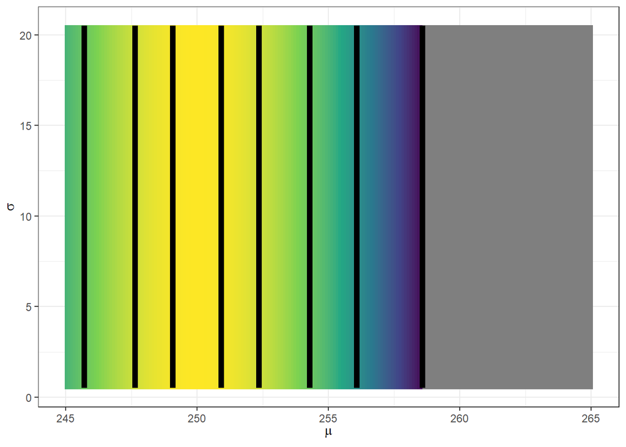

```r
param_grid %>%
  mutate(log_dens = log_prior_result) %>%
  mutate(log_dens_2 = log_dens - max(log_dens)) %>%
  ggplot(mapping = aes(x = mu, y = sigma)) +
  geom_raster(mapping = aes(fill = log_dens_2)) +
  stat_contour(mapping = aes(z = log_dens_2),
               breaks = log(c(0.01/100, 0.01, 0.1, 0.5, 0.9)),
               size = 2.2,
               color = "black") +
  scale_fill_viridis_c(guide = FALSE,
                       limits = log(c(0.01/100, 1.0))) +
  labs(x = expression(mu), y = expression(sigma)) +
  theme_bw()
```

```r
my_logpost <- function(theta, my_info)
{
  lik_mu <- theta[1]
  lik_sigma <- theta[2]

  # calculate the log-likelihood
  log_lik <- sum(dnorm(x = my_info$xobs,
                       mean = lik_mu,
                       sd = lik_sigma,
                       log = TRUE))

  log_prior <- dnorm(x = lik_mu,
        mean = my_info$mu_0,
        sd = my_info$tau_0,
        log = TRUE) +
    dunif(x = lik_sigma,
          min = my_info$sigma_lwr,
          max = my_info$sigma_upr,
          log = TRUE)

  # sum together
  log_lik + log_prior
}
```

Visualize the log-posterior.

```r
info_N05 <- list(
  xobs = x[1:5],
  mu_0 = 250,
  tau_0 = 2,
  sigma_lwr = 0.5,
  sigma_upr = 20.5
)

log_post_result <- purrr::map2_dbl(param_grid$mu,
                                    param_grid$sigma,
                                    eval_logdensity,
                                    func_logdens = my_logpost,
                                    my_info = info_N05)
```

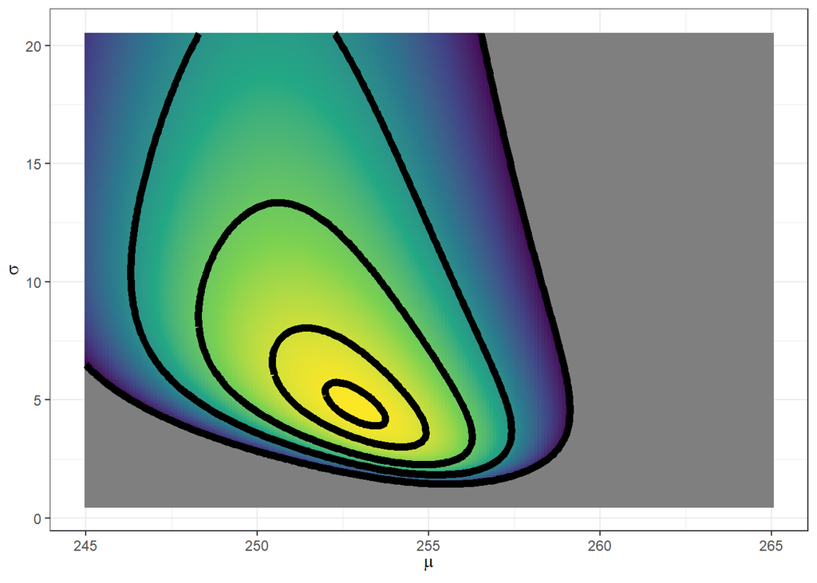

```r
param_grid %>%
  mutate(log_dens = log_post_result) %>%
  mutate(log_dens_2 = log_dens - max(log_dens)) %>%
  ggplot(mapping = aes(x = mu, y = sigma)) +
  geom_raster(mapping = aes(fill = log_dens_2)) +
  stat_contour(mapping = aes(z = log_dens_2),
               breaks = log(c(0.01/100, 0.01, 0.1, 0.5, 0.9)),
               size = 2.2,
               color = "black") +
  scale_fill_viridis_c(guide = FALSE,
                       limits = log(c(0.01/100, 1.0))) +
  labs(x = expression(mu), y = expression(sigma)) +
  theme_bw()
```

Use the `optim()` function to perform the optimization.

```r
map_result <- optim(c(250, 10),
                    my_logpost,
                    gr = NULL,
                    info_N05,
                    method = "BFGS",
                    hessian = TRUE,
                    control = list(fnscale = -1, maxit = 1001))

map_result
```

```
## $par
## [1] 252.897971   4.701953
##
## $value
## [1] -20.49227
##
## $counts
## function gradient
##       19       15
##
## $convergence
## [1] 0
##
## $message
## NULL
##
## $hessian
##            [,1]       [,2]
## [1,] -0.4761588 -0.3081777
## [2,] -0.3081777 -0.4523411
```

Try from another starting guess.

```r
map_result_2 <- optim(c(260, 2),
                    my_logpost,
                    gr = NULL,
                    info_N05,
                    method = "BFGS",
                    hessian = TRUE,
                    control = list(fnscale = -1, maxit = 1001))
map_result_2
```

```
## $par
## [1] 252.897876   4.702038
##
## $value
## [1] -20.49227
##
## $counts
## function gradient
##       20       16
##
## $convergence
## [1] 0
##
## $message
## NULL
##
## $hessian
##            [,1]       [,2]
## [1,] -0.4761506 -0.3081700
## [2,] -0.3081700 -0.4523186
```

Instead of finding the posterior mode on $\mu$ and $\sigma$, find the posterior mode on $\mu$ and the unbounded $\varphi$.

Define a new log-posterior function on the transformed parameters.

```r
my_logpost_cv <- function(phi, my_info)
{
  lik_mu <- phi[1]
  lik_varphi <- phi[2]

  # back transform from phi to sigma
  lik_sigma <- my_info$sigma_lwr + (my_info$sigma_upr - my_info$sigma_lwr) * boot::inv.logit(lik_varphi)

  # calculate the log-likelihood
  log_lik <- sum(dnorm(x = my_info$xobs,
                       mean = lik_mu,
                       sd = lik_sigma,
                       log = TRUE))

  # calculate the log-prior on mu
  log_prior_mu <- dnorm(x = lik_mu,
                        mean = my_info$mu_0,
                        sd = my_info$tau_0,
                        log = TRUE)

  # calculate the log-prior on sigma
  log_prior_sigma <- dunif(x = lik_sigma,
                           min = my_info$sigma_lwr,
                           max = my_info$sigma_upr,
                           log = TRUE)

  # account for the log-derivative adjustment
  log_deriv_adjust <- log(my_info$sigma_upr - my_info$sigma_lwr) +
    log(boot::inv.logit(lik_varphi)) +
    log(1 - boot::inv.logit(lik_varphi))

  # sum the terms together
  log_lik + log_prior_mu + log_prior_sigma + log_deriv_adjust
}
```

Run the optimization on the transformed parameters.

```r
map_res_cv <- optim(c(260, -2),
                    my_logpost_cv,
                    gr = NULL,
                    info_N05,
                    method = "BFGS",
                    hessian = TRUE,
                    control = list(fnscale = -1, maxit = 1001))

map_res_cv
```

```
## $par
## [1] 252.469818  -1.119516
##
## $value
## [1] -19.23514
##
## $counts
## function gradient
##       16       11
##
## $convergence
## [1] 0
##
## $message
## NULL
##
## $hessian
##            [,1]       [,2]
## [1,] -0.4200778 -0.8454491
## [2,] -0.8454491 -4.2700749
```

Try another initial guess.

```r
map_res_cv_2 <- optim(c(248, 2),
                    my_logpost_cv,
                    gr = NULL,
                    info_N05,
                    method = "BFGS",
                    hessian = TRUE,
                    control = list(fnscale = -1, maxit = 1001))

map_res_cv_2
```

```
## $par
## [1] 252.470708  -1.119692
##
## $value
## [1] -19.23514
##
## $counts
## function gradient
##       20       11
##
## $convergence
## [1] 0
##
## $message
## NULL
##
## $hessian
##            [,1]      [,2]
## [1,] -0.4201188 -0.845472
## [2,] -0.8454720 -4.270232
```

Set up the the laplace approximation function.

```r
my_laplace <- function(start_guess, logpost_func, ...)
{
  # code adapted from the `LearnBayes`` function `laplace()`
  fit <- optim(start_guess,
               logpost_func,
               gr = NULL,
               ...,
               method = "BFGS",
               hessian = TRUE,
               control = list(fnscale = -1, maxit = 1001))

  mode <- fit$par
  h <- -solve(fit$hessian)
  p <- length(mode)
  int <- p/2 * log(2 * pi) + 0.5 * log(det(h)) + logpost_func(mode, ...)
  list(mode = mode,
       var_matrix = h,
       log_evidence = int,
       converge = ifelse(fit$convergence == 0,
                         "YES",
                         "NO"),
       iter_counts = fit$counts[1])
}
```

Perform the laplace approximation.

```r
laplace_result <- my_laplace(c(260, -2), my_logpost_cv, info_N05)

laplace_result
```

```
## $mode
## [1] 252.469818  -1.119516
##
## $var_matrix
##            [,1]       [,2]
## [1,]  3.9575122 -0.7835635
## [2,] -0.7835635  0.3893288
##
## $log_evidence
## [1] -17.43527
##
## $converge
## [1] "YES"
##
## $iter_counts
## function
##       16
```

Use random sampling to back transform to $\sigma$.

```r
generate_post_samples <- function(mvn_result, N, my_info)
{
  MASS::mvrnorm(n = N,
                mu = mvn_result$mode,
                Sigma = mvn_result$var_matrix) %>%
    as.data.frame() %>% tbl_df() %>%
    purrr::set_names(c("mu", "varphi")) %>%
    mutate(sigma = my_info$sigma_lwr + (my_info$sigma_upr - my_info$sigma_lwr) * boot::inv.logit(varphi))
}
```

Generate the random posterior samples.

```r
set.seed(712712)
my_post_samples <- generate_post_samples(laplace_result, N = 1e4, info_N05)

my_post_samples
```

```
## # A tibble: 10,000 x 3
##       mu  varphi sigma
##    <dbl>   <dbl> <dbl>
##  1  254. -2.39    2.18
##  2  253. -0.894   6.30
##  3  254. -0.0243 10.4
##  4  255. -1.70    3.58
##  5  254. -2.37    2.21
##  6  247. -0.169   9.66
##  7  251. -0.254   9.24
##  8  253. -0.494   8.08
##  9  253. -0.0216 10.4
## 10  256. -1.83    3.28
## # ... with 9,990 more rows
```

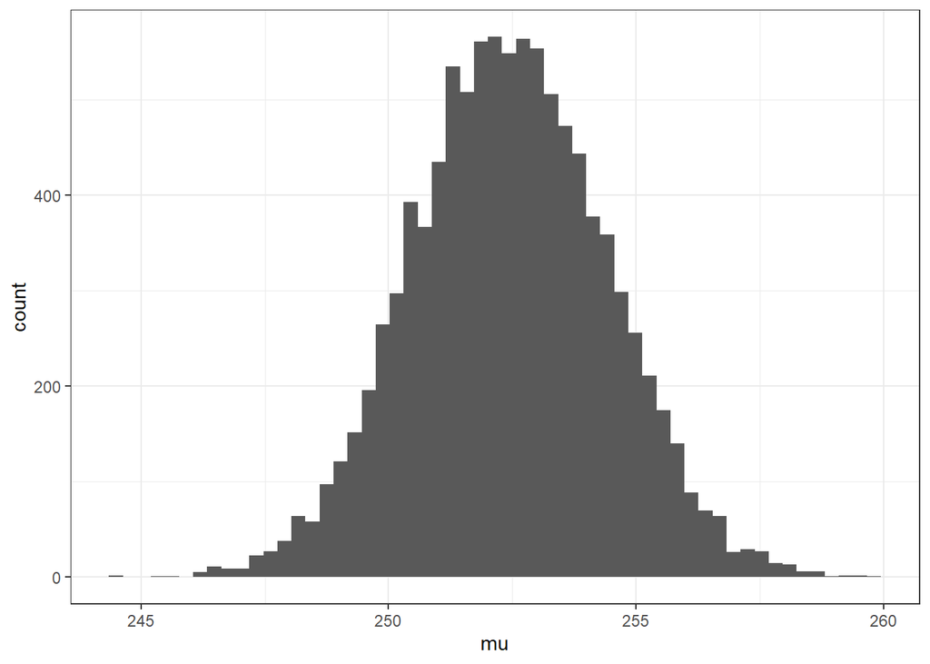

```r
my_post_samples %>%
  ggplot(mapping = aes(x = mu)) +
  geom_histogram(bins = 55) +
  theme_bw()
```

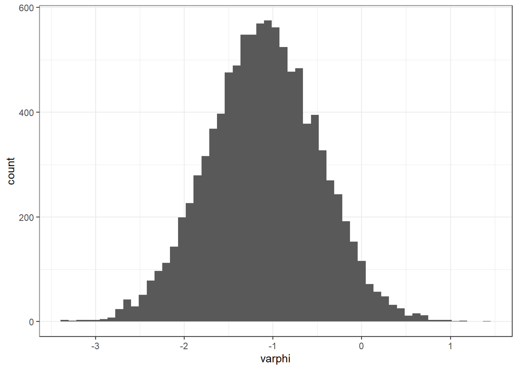

```r
my_post_samples %>%
  ggplot(mapping = aes(x = varphi)) +
  geom_histogram(bins = 55) +
  theme_bw()
```

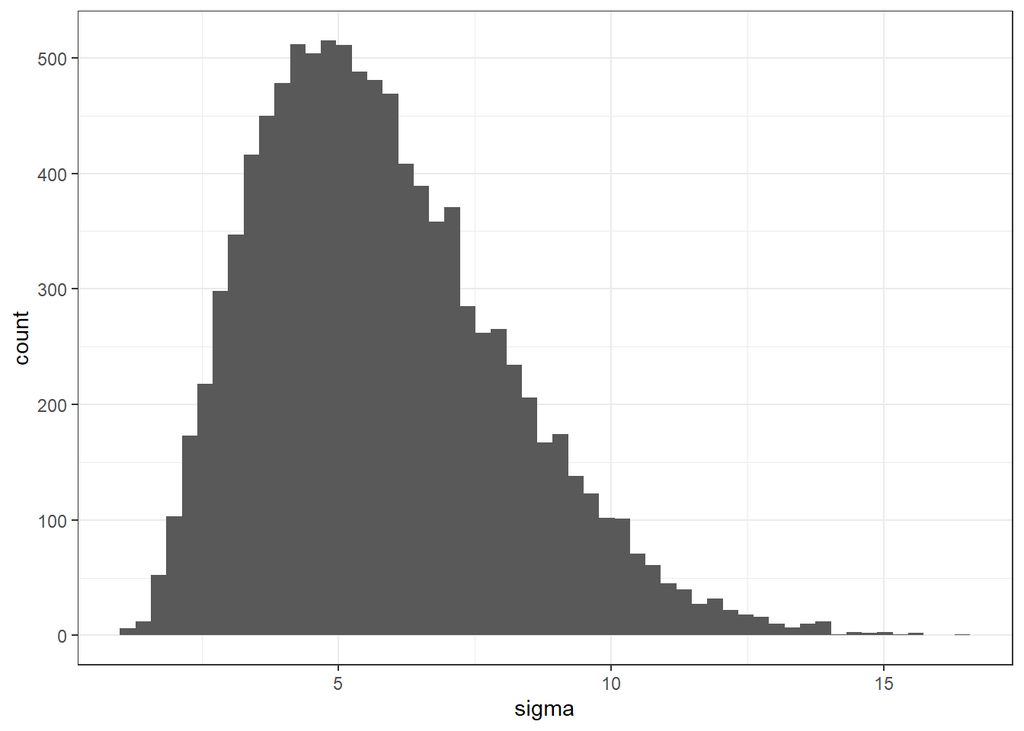

```r
my_post_samples %>%
  ggplot(mapping = aes(x = sigma)) +
  geom_histogram(bins = 55) +
  theme_bw()
```